# Regression and model validation

This section is the report for the second week of IODS. To start with, here are the instructions given for writing this report:

> *Describe the work you have done this week and summarize your learning.*
> - Describe your work and results clearly.
> - Assume the reader has an introductory course level understanding of writing and reading R code as well as statistical methods.
> - Assume the reader has no previous knowledge of your data or the more advanced methods you are using.

With that out of the way, let’s start the analysis part of the current exercise set!

## Setting up

First, I need to include a couple of libraries to properly build (or rather, “knit”) this report.

```r
# knitr is used to build this report, so it is included by default

# Remove the '##' from each line of R output blocks
knitr::opts_chunk$set(comment = '')

# Libraries for convenience
library(dplyr)
library(ggplot2)
library(GGally)
library(gridExtra)

# NOTE: Messages are omitted
```

## The analysis data

The analysis data was produced in “Data wrangling” part of the exercises. The original data is the “JYTOPKYS2” study data by Kimmo Vehkalahti. The original data is available from [here](https://www.mv.helsinki.fi/home/kvehkala/JYTmooc/JYTOPKYS3-data.txt) and the data is explained [here](https://www.mv.helsinki.fi/home/kvehkala/JYTmooc/JYTOPKYS2-meta.txt).

The analysis data is a mix of original variables (`gender`, `age`, `attitude`, and `points`) and derived variables (`deep`, `stra`, and `surf`). The original and derived variables are explained as following, based on Vehkalahti’s metadata. Note that the derived variables were omitted from the original data linked above – so that we’d have to calculate them ourselves – but they were included in the metadata.

| Variable | Meaning | Type | Notes |
| --- | --- | --- | --- |
| `gender` | Gender of the student | Categorical | “M” or “F” |
| `age` | Age (in years) | Number | derived from the date of birth |
| `attitude` | Global attitude toward statistics | Number | Sum of 10 answers |
| `points` | Total points from coursework | Number | Student’s best exam score + extra points from answering the study questionnaire |
| `deep` | Average score of answers related to Deep approach | Number | Avg. of 12 answers |
| `stra` | Average score of answers related to Strategic approach | Number | Avg. of 12 answers |
| `surf` | Average score of answers related to Surface approach | Number | Avg. of 8 answers |

You can see the creation script [here](https://github.com/pkars/IODS-project/blob/master/data/create_learning2014.R) (most recent version) or the original from [commit `bb6de84`](https://github.com/pkars/IODS-project/blob/bb6de848b26bd4fbd3e909cce19831c8d86ccbee/data/create_learning2014.R)). The script stores the data to `learning2014.csv`, so let’s start by reading that file and printing out the dataset structure, first few rows[^1], and some summary statistics.

```r
dset <- read.csv("data/learning2014.csv")
```

```r
str(dset)
```

```
'data.frame':   166 obs. of  7 variables:
 $ gender  : chr  "F" "M" "F" "M" ...
 $ age     : int  53 55 49 53 49 38 50 37 37 42 ...
 $ attitude: int  37 31 25 35 37 38 35 29 38 21 ...
 $ deep    : num  3.58 2.92 3.5 3.5 3.67 ...
 $ stra    : num  3.38 2.75 3.62 3.12 3.62 ...
 $ surf    : num  2.58 3.17 2.25 2.25 2.83 ...
 $ points  : int  25 12 24 10 22 21 21 31 24 26 ...
```

```r
knitr::kable(head(dset, 5))  # Prettier table, see also footnote
```

| gender | age | attitude | deep | stra | surf | points |
| --- | --- | --- | --- | --- | --- | --- |
| F | 53 | 37 | 3.583333 | 3.375 | 2.583333 | 25 |
| M | 55 | 31 | 2.916667 | 2.750 | 3.166667 | 12 |
| F | 49 | 25 | 3.500000 | 3.625 | 2.250000 | 24 |
| M | 53 | 35 | 3.500000 | 3.125 | 2.250000 | 10 |
| M | 49 | 37 | 3.666667 | 3.625 | 2.833333 | 22 |

```r
summary(dset)
```

```
    gender               age           attitude          deep
 Length:166         Min.   :17.00   Min.   :14.00   Min.   :1.583
 Class :character   1st Qu.:21.00   1st Qu.:26.00   1st Qu.:3.333
 Mode  :character   Median :22.00   Median :32.00   Median :3.667
                    Mean   :25.51   Mean   :31.43   Mean   :3.680
                    3rd Qu.:27.00   3rd Qu.:37.00   3rd Qu.:4.083
                    Max.   :55.00   Max.   :50.00   Max.   :4.917
      stra            surf           points
 Min.   :1.250   Min.   :1.583   Min.   : 7.00
 1st Qu.:2.625   1st Qu.:2.417   1st Qu.:19.00
 Median :3.188   Median :2.833   Median :23.00
 Mean   :3.121   Mean   :2.787   Mean   :22.72
 3rd Qu.:3.625   3rd Qu.:3.167   3rd Qu.:27.75
 Max.   :5.000   Max.   :4.333   Max.   :33.00
```

```r
count(dset, gender)
```

```
  gender   n
1      F 110
2      M  56
```

This data contains 166 data points (rows). The original data has 187 rows, however the students with 0 points were omitted during the data wrangling. Out of the 166 remaining students, 110 were female and 56 were male. The students’ age ranges from 17 to 55 years, with median at 22 years.

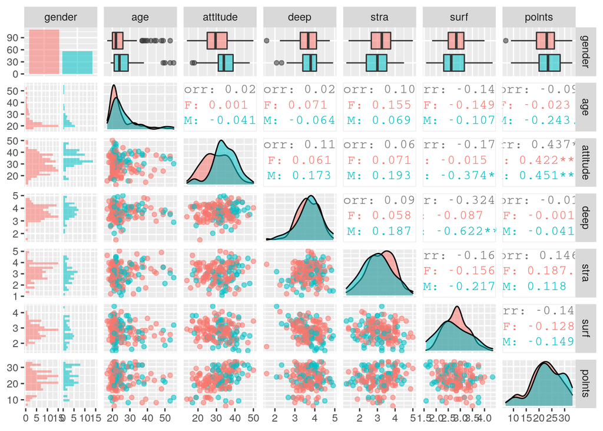

```r
ggpairs(dset,
        mapping = aes(col = gender, alpha = 0.3),
        lower = list(combo=wrap("facethist", bins=20))
       )
```

```r
cor(dset[-1])  # Exclude 'gender' column
```

```
                 age    attitude        deep        stra       surf      points
age       1.00000000  0.02220071  0.02507804  0.10244409 -0.1414052 -0.09319032
attitude  0.02220071  1.00000000  0.11024302  0.06174177 -0.1755422  0.43652453
deep      0.02507804  0.11024302  1.00000000  0.09650255 -0.3238020 -0.01014849
stra      0.10244409  0.06174177  0.09650255  1.00000000 -0.1609729  0.14612247
surf     -0.14140516 -0.17554218 -0.32380198 -0.16097287  1.0000000 -0.14435642
points   -0.09319032  0.43652453 -0.01014849  0.14612247 -0.1443564  1.00000000
```

## Fitting the linear model

Next up is a task to fit a linear model to the data, where `points` is the target variable and one or more other variables are the explanatory variables. First instruction was to select three explanatory variables. I chose `attitude`, `stra`, and `surf` as their correlation coefficients with `points` were the largest (absolute value). And the results are…

```r
# Target: points
# Explanatory variables (3): attitude, stra, surf
#   based on absolute value of correlation coefficient (Pearson)
model <- lm(points ~ attitude + stra + surf, dset)
summary(model)
```

```
Call:
lm(formula = points ~ attitude + stra + surf, data = dset)

Residuals:
     Min       1Q   Median       3Q      Max
-17.1550  -3.4346   0.5156   3.6401  10.8952

Coefficients:
            Estimate Std. Error t value Pr(>|t|)
(Intercept) 11.01711    3.68375   2.991  0.00322 **
attitude     0.33952    0.05741   5.913 1.93e-08 ***
stra         0.85313    0.54159   1.575  0.11716
surf        -0.58607    0.80138  -0.731  0.46563
---
Signif. codes:  0 '***' 0.001 '**' 0.01 '*' 0.05 '.' 0.1 ' ' 1

Residual standard error: 5.296 on 162 degrees of freedom
Multiple R-squared:  0.2074,    Adjusted R-squared:  0.1927
F-statistic: 14.13 on 3 and 162 DF,  p-value: 3.156e-08
```

Yeah, not so good. First, I’ll have to quickly interpret the output. First is the distribution of residuals. A (minimum) residual of “-17” seems rather large (it’s absolute value, that is), when the points range from 7 to 33 – there might be some strong outliers. At least median is close to zero, which is reassuring. Next are the coefficients for the linear regression. The `estimate` column shows the slope of the linear regression (except for the intercept it shows the value of “target” when all explanatory variables are zero). So having zero attitude and learning strategies you’d expect a student to get 11 points. For the slopes, the value means “the increase or decrease in points, when attitude/strategic learning/surface learning value increases by one unit”. So, having larger `attitude` and `stra` scores would indicate better performance, whereas larger `surf` score would decrease performance. Next column, `Std. Error`, shows the standard error of the estimate. Third column, `t value`, shows the t-statistic – which is a measure of the estimates statistical significance. However that value is rather transient by itself, so we’ll rely on the fourth column to interpret the t-statistic. This column shows the *probability of having this particular non-zero value for estimate by random chance*, or in other words, how confident we can be in rejecting the null hypothesis. One more time for the non-statisticians like me: the smaller p-value is, the more we can trust that our target and explanatory variable have a relationship – i.e. the slope is not zero. Other interesting numbers are the R-squared values: they estimate “the fraction of variance explained by the model”. Zero means that our model cannot explain anything about the target variable, while one would mean that our model explains everything, including any random errors.

So, looking at the significance of the estimates, it looks like that only the `attitude` has any explaining power here. But `stra` is close. The R<sup>2</sup> values indicate that we’re not capturing the majority of the variance with this model – or that our data is really noisy and has plenty of unknown random errors. Let’s try to improve the model by dropping `surf` as it is not meaningful at all; maybe it masks `stra` a little.

```r
model <- lm(points ~ attitude + stra, dset)
summary(model)
```

```
Call:
lm(formula = points ~ attitude + stra, data = dset)

Residuals:
     Min       1Q   Median       3Q      Max
-17.6436  -3.3113   0.5575   3.7928  10.9295

Coefficients:
            Estimate Std. Error t value Pr(>|t|)
(Intercept)  8.97290    2.39591   3.745  0.00025 ***
attitude     0.34658    0.05652   6.132 6.31e-09 ***
stra         0.91365    0.53447   1.709  0.08927 .
---
Signif. codes:  0 '***' 0.001 '**' 0.01 '*' 0.05 '.' 0.1 ' ' 1

Residual standard error: 5.289 on 163 degrees of freedom
Multiple R-squared:  0.2048,    Adjusted R-squared:  0.1951
F-statistic: 20.99 on 2 and 163 DF,  p-value: 7.734e-09
```

Well, there is a slight improvement for `stra`. Also, the intercept got more significant! Cool. Also, adjusted R<sup>2</sup> slightly improved. However, the `stra` is still a little suspect whether it truly has some explaining power. Let’s inspect it a little further by *plotting* the scatterplots for `points ~ attitude` and `points ~ stra`:

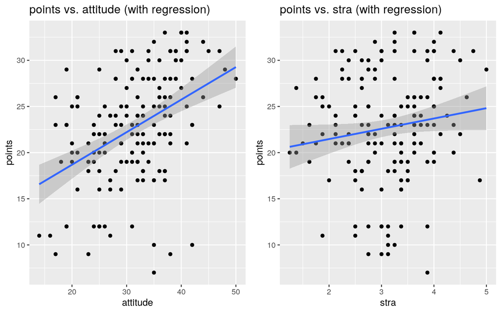

```r
# Do scatterplots with ggplot2: prettier figures and include a linear regression fit easily!
p_att <- ggplot(dset, mapping=aes(attitude, points)) +         # Set up the figure
           geom_point() +                                      # Add scatter points
           geom_smooth(method="lm") +                          # Add linear regression with confidence interval
           labs(title="points vs. attitude (with regression)") # Add title for the plot

p_stra <- ggplot(dset, mapping=aes(stra, points)) +
            geom_point() +
            geom_smooth(method="lm") +
            labs(title="points vs. stra (with regression)")

# Use gridExtra package to present the figures side-by-side. Saves some screen space :)
grid.arrange(p_att, p_stra, nrow=1, ncol=2)
```

Okay, so, the left and right figures have `attitude` and `stra` respectively as explanatory variable. As expected, `attitude` shows at least some linear pattern in the scatter plot. Though there are some points rather far away from the regression line (I’ll explore this in a bit)… On the contrary, `stra` plot doesn’t seem to have any discernible pattern, and the regression line’s slope is quite close to zero. So I’m not convinced that `stra` would be a good explanatory variable here. Let’s see what happens when I drop `stra` also…

```r
model <- lm(points ~ attitude, dset)
summary(model)
```

```
Call:
lm(formula = points ~ attitude, data = dset)

Residuals:
     Min       1Q   Median       3Q      Max
-16.9763  -3.2119   0.4339   4.1534  10.6645

Coefficients:
            Estimate Std. Error t value Pr(>|t|)
(Intercept) 11.63715    1.83035   6.358 1.95e-09 ***
attitude     0.35255    0.05674   6.214 4.12e-09 ***
---
Signif. codes:  0 '***' 0.001 '**' 0.01 '*' 0.05 '.' 0.1 ' ' 1

Residual standard error: 5.32 on 164 degrees of freedom
Multiple R-squared:  0.1906,    Adjusted R-squared:  0.1856
F-statistic: 38.61 on 1 and 164 DF,  p-value: 4.119e-09
```

Yes, there is some change. Most drastic change is in intercept’s significance: the t-value nearly doubled and the corresponding probability value became five magnitudes smaller. Also, the residuals minimum, maximum, and median got all a little closer to zero. Although both multiple and adjusted R<sup>2</sup> value took a minor hit (they weren’t very high to begin with, though). Speaking of R<sup>2</sup> values being low, looks like our simple linear model explains only about 19% of the variance. That might be acceptable for this study, but I’d be cautious to use this model in forecasting. Regardless, it shows that there is a relationship between the two variables.

## Interpreting the model and the model diagnostics

So, based on the above analysis, the student’s attitude towards statistics can indicate their course performance: more enthusiastic student is likely to perform better than a student who is not very interested in statistics. However, having a good attitude towards statistics won’t guarantee them success! There must be something else, as the scatter plot for `points ~ attitude` hints: the points are rather spread out from the regression line.

To conclude the analysis, I’ll study the model’s diagnostics a bit. A good data science practice calls for critical evaluation of the model – you shouldn’t blindly trust a model output without knowing if the model is reliable and trustworthy. In linear regression, we implicitly assume a couple of things about our random errors:

1. The errors are normally distributed
2. The error distribution has a zero mean and a constant variance
3. The errors are not correlated with each other

Then, there is a question of outliers, which are data points that deviate from the main body of data points. Does our data have outliers, that will distort the fitting process by having strong “leverage”? The third plot, “Residuals vs Leverage” answers this question. As the leverages are quite small (<0.05), there doesn’t seem to be any data points that would affect our fit disproportionately. Turns out the data points with large residuals were close to the centerpoint of the linear fit, so they didn’t have that much leverage.

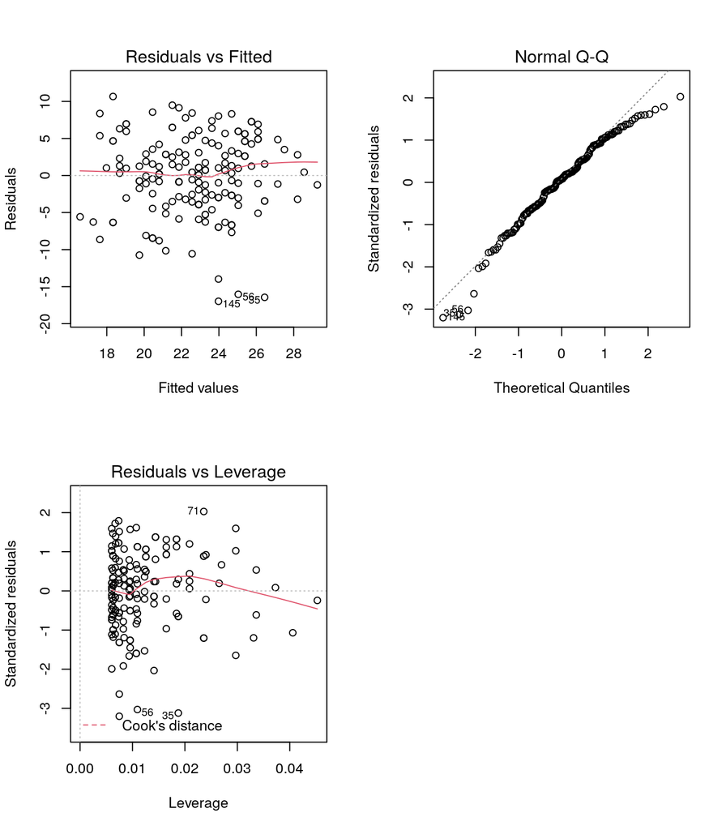

```r
par(mfrow = c(2,2))
plot(model, which=c(1,2,5))
```

[^1]: I’m using the `knitr::kable` function here to output prettier tables. It doesn’t affect the data values in any way, it is a purely aesthetic helper function.